# Counting reads

Noelle Wheeler

2023-02-27

#### 1. Use feature counts to count the number of reads that overlap with every exon.

```
$ mkdir gene_counts
$ featureCounts -a /home/luce/angsd/referenceGenomes/sacCer3.sgd.gtf -o /athena/angsd/scratch/naw4005/gene_counts/gierlinksi_fc_exon /home/luce/angsd/gierlinski/alignments/SNF2_1.Aligned.sortedByCoord.out.bam
/home/luce/angsd/gierlinski/alignments/SNF2_2.Aligned.sortedByCoord.out.bam
/home/luce/angsd/gierlinski/alignments/SNF2_3.Aligned.sortedByCoord.out.bam
/home/luce/angsd/gierlinski/alignments/SNF2_4.Aligned.sortedByCoord.out.bam
/home/luce/angsd/gierlinski/alignments/SNF2_5.Aligned.sortedByCoord.out.bam
/home/luce/angsd/gierlinski/alignments/WT_1.Aligned.sortedByCoord.out.bam
/home/luce/angsd/gierlinski/alignments/WT_2.Aligned.sortedByCoord.out.bam
/home/luce/angsd/gierlinski/alignments/WT_3.Aligned.sortedByCoord.out.bam
/home/luce/angsd/gierlinski/alignments/WT_4.Aligned.sortedByCoord.out.bam
/home/luce/angsd/gierlinski/alignments/WT_5.Aligned.sortedByCoord.out.bam
-f --tmpDir /athena/angsd/scratch/naw4005
```

The -t parameter specifies the feature type(s) in a GTF annotation. The default is ‘exon’ so I kept the default value since I would like the count the number of reads that overlap with every exon. I added the -f parameter so that it would count reads for exons rather than genes. The default value is gtf, so I kept the default value. I also set the -tmpDir parameter to be my scratch directory because this is where the temporary directory is stored.

#### 2. Generate a bar plot that displays the numbers of assigned and unassigned reads for either featureCounts run.

```r
library(dplyr)
library(tidyr)
folder <- "/Users/noelawheeler/Desktop/Analysis of next gen seq data/Analysis-Next-Gen-Sequencing/counting_reads/"
readcounts_gene <- read.table(paste0(folder, "gierlinksi_fc.summary"), header = TRUE)
readcounts_exon <- read.table(paste0(folder, "gierlinksi_fc_exon.summary"), header = TRUE)
# take only non-zero rows
subset_readcounts_gene <- readcounts_gene[readcounts_gene$Status %in% c("Assigned", "Unassigned_Ambiguity", "Unassigned_MultiMapping", "Unassigned_NoFeatures"), ]
subset_readcounts_exon <- readcounts_exon[readcounts_exon$Status %in% c("Assigned", "Unassigned_Ambiguity", "Unassigned_MultiMapping", "Unassigned_NoFeatures"), ]

# change column names in exon dataset
orig_names <- colnames(subset_readcounts_exon)
names(subset_readcounts_exon) <- gsub(".*(WT|SNF2)(_[0-9]+).*", "\\1\\2", orig_names)

# change column names in gene dataset
orig_names <- colnames(subset_readcounts_gene)
names(subset_readcounts_gene) <- gsub(".*(WT|SNF2)(_[0-9]+).*", "\\1\\2", orig_names)

# make datasets long
df_long_gene <- pivot_longer(subset_readcounts_gene, cols = c("SNF2_1", "SNF2_2","SNF2_3", "SNF2_4","SNF2_5","WT_1","WT_2", "WT_3","WT_4","WT_5"), names_to = "Type", values_to = "Count")
df_long_exon <- pivot_longer(subset_readcounts_exon, cols = c("SNF2_1", "SNF2_2","SNF2_3", "SNF2_4","SNF2_5","WT_1","WT_2", "WT_3","WT_4","WT_5"), names_to = "Type", values_to = "Count")
```

plot results

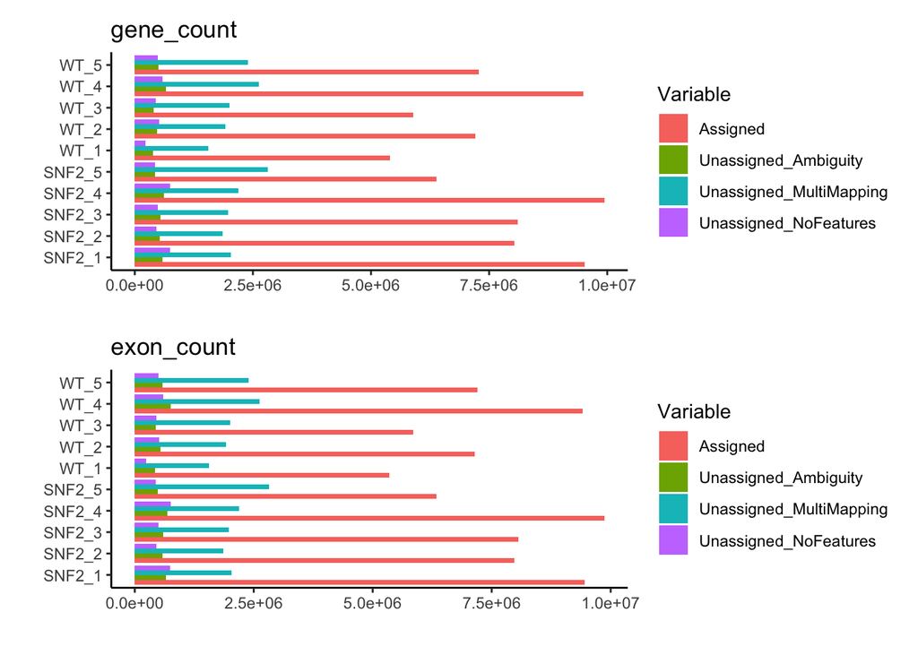

```r
library(ggplot2)
library(dplyr)
library(patchwork)
exon <- ggplot(df_long_exon, aes(x = Type, y = Count, fill = Status)) +
  geom_bar(stat = "identity", position = position_dodge(width = .9)) +
  scale_fill_hue(name = "Variable") +
  labs(title="exon_count",x="", y="") +
  theme_classic() + coord_flip()

gene <- ggplot(df_long_gene, aes(x = Type, y = Count, fill = Status)) +
  geom_bar(stat = "identity", position = position_dodge(width = .9)) +
  scale_fill_hue(name = "Variable") +
  labs(title="gene_count",x="", y="") +
  theme_classic() + coord_flip()
(gene/exon)
```

These plots show very similar results. One difference is that exon_count shows slightly higher unassigned_ambiguity values than gene_count, on average. Another difference is that in most samples the exon_count has lower counts for assigned mapping, however this difference is very small.

```
# download c. elegans gtf file
$ wget https://hgdownload.soe.ucsc.edu/goldenPath/ce11/bigZips/genes/ce11.ensGene.gtf.gz
$ zcat ce11.ensGene.gtf.gz | awk '{print $3}'| sort | uniq -c
```

28213 3UTR  
31088 5UTR  
225595 CDS  
273640 exon  
33575 start_codon  
33595 stop_codon  
61451 transcript